# recount workshop: Learn to leverage 70,000 human RNA-seq samples for your projects

## 2.2 Enriching the annotation

Data in recount2 can be used for annotation-agnostic analyses and enriching the known annotation. Just like exon and gene coverage count matrices, recount2 provides exon-exon junction count matrices. These matrices can be used to identify new isoforms (Figure 10) or identify differentially expressed isoforms. For example, exon-exon junctions 2, 5 and 6 in Figure 1 are only present in one annotated isoform. `Snaptron` (10) allows programatic and high-level queries of the exon-exon junction information and it is graphical user interface is specially useful for visualizing this data. Inside R, the `recount` function `snaptron_query()` can be used for searching specific exon-exon junctions in recount2.

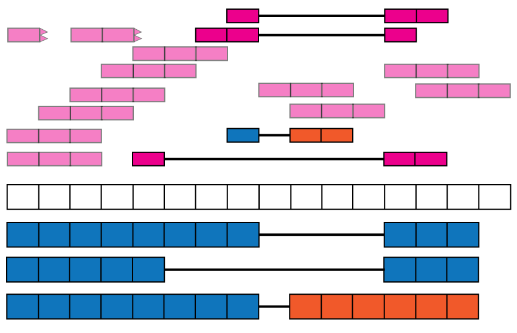

Figure 10: Exon-exon junctions go beyond the annotation  
Reads spanning exon-exon junctions are highlighted and compared against the annotation. Three of them match the annotated junctions, but one (blue and orange read) spans an un-annotated exon-exon junction with the left end matching the annotation and the right end hinting at a possible new isoform for this gene (blue and orange isoform).

The base-pair coverage data from recount2 can be used together with `derfinder` (8) to identify expressed regions of the genome, providing another annotation-agnostic analysis of the expression data. Using the function `expressed_regions()` we can identify regions of expression based on a given data set in recount2. These regions might overlap known exons but can also provide information about intron retention events (Figure 11), improve detection of exon boundaries (Figure 12), and help identify new exons (Fig 1) or expressed sequences in intergenic regions. Using `coverage_matrix()` we can compute a coverage matrix based on the expressed regions or another set of genomic intervals. The resulting matrix can then be used for a differential expression analysis, just like the exon, gene and exon-exon junction matrices.

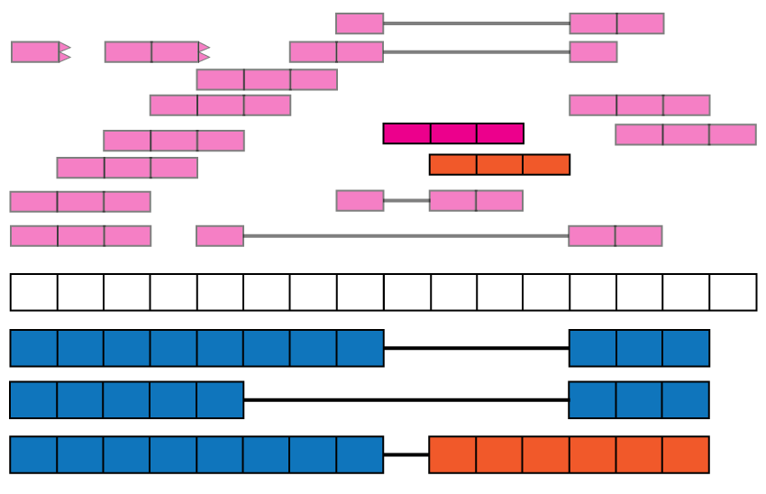

Figure 11: Intron retention events  
Some reads might align with known intronic segments of the genome and provide information for exploring intron retention events (pink read). Some might support an intron retention event or a new isoform when coupled with exon-exon junction data (orange read).

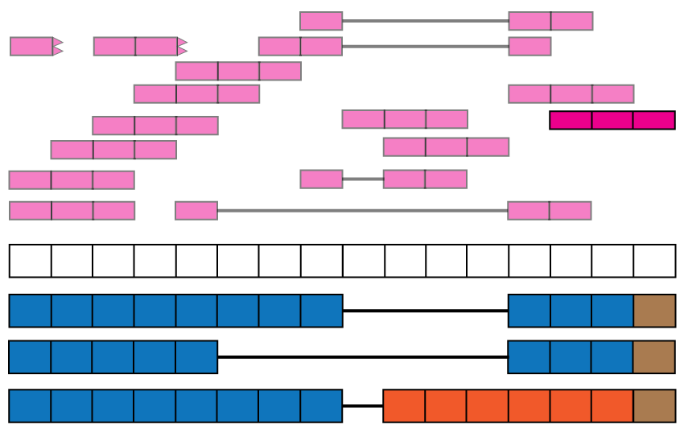

Figure 12: Exon boundaries  
Reads that go beyond the known exon boundaries can inform us of whether the annotated boundaries are correct or if there was a run-off transcription event.

# 3 Gene level analysis

Having reviewed how the coverage counts in recount2 were produced, we can now do a differential expression analysis. We will use data from GSE67333 (13) whose overall design was: *We performed directional RNA sequencing on high quality RNA samples extracted from hippocampi of 4 late onset Alzheimer’s disease (LOAD) and 4 age-matched controls.* The function `download_study()` requires a SRA accession id which can be found using `abstract_search()`. `download_study()` can then be used to download the gene coverage count data as well as other expression features. The files are saved in a directory named after the SRA accession id, in this case SRP056604.

To facilitate this workshop, we included the data in the `recountWorkshop` package. It can be located with the `system.file()` function as shown below.

```r
## Locate path with the data
library("recountWorkshop")
local_path <- system.file("extdata", "SRP056604", package = "recountWorkshop")
dir(local_path)
```

```
## [1] "SRP056604.tsv"   "SraRunTable.txt" "bw"              "rse_exon.Rdata"
## [5] "rse_gene.Rdata"
```

The commands should work with the data hosted from recount2 if there are no problems with the wifi connection. Although we prefer that you use the pre-installed data for this workshop.

```r
library("recount")

## Find the project id by searching abstracts of studies
abstract_search("hippocampi of 4")
```

```
##      number_samples species
## 1643              8   human
##                                                                                                                                                                                                                                                                                                          …
## 1643 Our data provide a comprehensive list of transcriptomics alterations and warrant holistic approach including both coding and non-coding RNAs in functional studies aimed to understand the pathophysiology of LOAD Overall design: We performed directional RNA sequencing on high quality RNA sampl…
##        project
## 1643 SRP056604
```

```r
## Download the data if it is not there
if(!file.exists(file.path(local_path, "rse_gene.Rdata"))) {
    ## In case you decide to download the data instead of using the
    ## pre-installed data
    local_path <- "SRP056604"
    download_study("SRP056604", type = "rse-gene")
}

## Check that the file was downloaded
file.exists(file.path(local_path, "rse_gene.Rdata"))
```

```
## [1] TRUE
```

```r
## Load the data
load(file.path(local_path, "rse_gene.Rdata"))
```

The coverage count matrices are provided as *RangedSummarizedExperiment* objects (rse) (9). These objects store information at the feature level, the samples and the actual count matrix as shown in Figure 1 of Love et al., 2016 (3). Figure 2 shows the actual rse objects provided by recount2 and how to access the different portions of the data. Using a unique sample id such as the SRA Run id it is possible to expand the sample metadata. This can be done using the predicted phenotype provided by `add_predictions()` (14), pulling information from GEO via `find_geo()` and `geo_characteristics()`, or with custom code.

## 3.1 Metadata

Using the `colData()` function we can access sample metadata. More information on these metadata is provided in the supplementary material of the recount2 paper (7), and we provide a brief review here. The rse objects for SRA data sets include 21 columns with mostly technical information. The GTEx and TCGA rse objects include additional metadata as available from the raw sources. In particular, we compiled metadata for GTEx using the v6 phenotype information available at gtexportal.org, and we put together a large table of TCGA case and sample information by combining information accumulated across [Seven Bridges’ Cancer Genomics Cloud](http://www.cancergenomicscloud.org/) and `TCGAbiolinks` (15).

```r
## One row per sample, one column per phenotype variable
dim(colData(rse_gene))
```

```
## [1]  8 21
```

```r
## Mostly technical variables are included
colnames(colData(rse_gene))
```

```
##  [1] "project"
##  [2] "sample"
##  [3] "experiment"
##  [4] "run"
##  [5] "read_count_as_reported_by_sra"
##  [6] "reads_downloaded"
##  [7] "proportion_of_reads_reported_by_sra_downloaded"
##  [8] "paired_end"
##  [9] "sra_misreported_paired_end"
## [10] "mapped_read_count"
## [11] "auc"
## [12] "sharq_beta_tissue"
## [13] "sharq_beta_cell_type"
## [14] "biosample_submission_date"
## [15] "biosample_publication_date"
## [16] "biosample_update_date"
## [17] "avg_read_length"
## [18] "geo_accession"
## [19] "bigwig_file"
## [20] "title"
## [21] "characteristics"
```

### 3.1.1 Technical variables

Several of these technical variables include the number of reads as reported by SRA, the actual number of reads Rail-RNA was able to download (which might be lower in some cases), the number of reads mapped by Rail-RNA, whether the sample is paired-end or not, the coverage AUC and the average read length (times 2 for paired-end samples). Note that sample with SRA Run id SRR2071341 has about 240.8 million reads as reported by SRA, while it has 120.4 million spots reported in https://trace.ncbi.nlm.nih.gov/Traces/sra/?run=SRR2071341; that is because it is a paired-end sample (2 reads per spot). These details are important for those interested on writing alternative scaling functions to `scale_counts()`.

```r
## Input reads: number reported by SRA might be larger than number
## of reads Rail-RNA downloaded
colData(rse_gene)[, c("read_count_as_reported_by_sra", "reads_downloaded")]
```

```
## DataFrame with 8 rows and 2 columns
##            read_count_as_reported_by_sra reads_downloaded
##                                <integer>        <integer>
## SRR1931819                     170053030        170053030
## SRR1931818                     164772379        164772379
## SRR1931817                     173894719        173894719
## SRR1931816                     177108169        177108169
## SRR1931815                     188604801        188604801
## SRR1931814                     178521597        178521597
## SRR1931813                     180318237        180318237
## SRR1931812                     187514717        187514717
```

```r
summary(colData(rse_gene)$proportion_of_reads_reported_by_sra_downloaded)
```

```
##    Min. 1st Qu.  Median    Mean 3rd Qu.    Max.
##       1       1       1       1       1       1
```

```r
## AUC information used by scale_counts() by default
head(colData(rse_gene)$auc)
```

```
## [1] 14058249889 13996129504 13578647527 14599138400 16423440640 15559854293
```

```r
## Alternatively, scale_scounts() can use the number of mapped reads
## and other information
colData(rse_gene)[, c("mapped_read_count", "paired_end", "avg_read_length")]
```

```
## DataFrame with 8 rows and 3 columns
##            mapped_read_count paired_end avg_read_length
##                    <integer>  <logical>       <integer>
## SRR1931819         160584474      FALSE              99
## SRR1931818         155722526      FALSE              99
## SRR1931817         164110375      FALSE              99
## SRR1931816         165119594      FALSE              99
## SRR1931815         180961318      FALSE              99
## SRR1931814         170579381      FALSE              99
## SRR1931813         171525236      FALSE              99
## SRR1931812         178912737      FALSE              99
```